# Distrito Capital. Densidad poblacional

Beatriz Valdez

30 de septiembre de 2016

## Pre-procesamiento de la data

```r
# Cambio el directorio de trabajo
setwd("D:/clasesInsumos/clases2016I/dtoCapital/distrito-capital")
# confirmar mi directorio de trabajo
getwd()
```

Obtengo la data relacionada con la densidad poblacional

```r
# subo la data densidad
densidad <- read_excel("d:/clasesInsumos/clases2016I/dtoCapital/Poblacion4.xls",
                        col_names = FALSE, skip = 11)
names(densidad) <-c("parroquia", "superficie", "poblacion",
                            "densidad")

# elimino las filas 23 en adelante
densidad <- densidad[1:22,]
```

Crearé una tabla para ver la información que tengo allí. El objetivo, en realidad, es mostrar cómo crear una tabla que pueda emplearse luego en un informe. Si sólo se desea explorar la data, basta con usar, por ejemplo, la función **head()**. Subo el paquete que me permitirá hacer la tabla (es uno de los tantos paquetes con los que se puede hacer una tabla):

```r
require(knitr)

# verifico el contenido del marco de datos
head(densidad)
```

```
## # A tibble: 6 × 4
##    parroquia superficie poblacion  densidad
##        <chr>      <dbl>     <dbl>     <dbl>
## 1 Altagracia        3.7     55954 15122.703
## 2   Antímano       29.5    131648  4462.644
## 3 Candelaria        1.2     74178 61815.000
## 4   Caricuao       24.8    152829  6162.460
## 5   Catedral        1.0     16144 16144.000
## 6      Coche       13.0     60093  4622.538
```

Creo la tabla. Voy a emplear la función **as.data.frame()**. Si usted leyó la hoja de cálculo de excel usando el paquete **readxl**, debe usar también esta función, de lo contrario escribe directamente el nombre. Observe que he colocado comentarios para explicar qué significa cada parámetro:

```r
# transformo el tibble en data.frame
dcDensidad <- as.data.frame(densidad)

# genero la tabla
kable(dcDensidad, # el data.frame. Note que lo usare completo
      digits= 1, # para indicar que deseo 1 decimal
      row.names= FALSE, # para que no aparezcan numeros como fila
      col.names = c("Parroquia", "Superficie",
                    "Poblacion", "Densidad"), # aprovecho y pongo los nombres de las columnas en mayuscula. Igual los podria cambiar tambien
      caption ="Distrito Capital segun poblacion y superficie", # para colocar el titulo del grafico
      format.args = list(decimal.mark = ",", big.mark = ".") # asi, los decimales se separan con coma y  la marca de mil lleva punto
      )
```

Distrito Capital segun poblacion y superficie

| Parroquia | Superficie | Poblacion | Densidad |
| --- | --- | --- | --- |
| Altagracia | 3,7 | 55.954 | 15.122,7 |
| Antímano | 29,5 | 131.648 | 4.462,6 |
| Candelaria | 1,2 | 74.178 | 61.815,0 |
| Caricuao | 24,8 | 152.829 | 6.162,5 |
| Catedral | 1,0 | 16.144 | 16.144,0 |
| Coche | 13,0 | 60.093 | 4.622,5 |
| El Junquito | 56,0 | 51.784 | 924,7 |
| El Paraíso | 10,4 | 122.204 | 11.750,4 |
| El Recreo | 18,1 | 127.425 | 7.040,1 |
| El Valle | 31,1 | 147.106 | 4.730,1 |
| La Pastora | 7,6 | 83.713 | 11.014,9 |
| La Vega | 12,9 | 124.926 | 9.684,2 |
| Macarao | 131,4 | 47.322 | 360,1 |
| San Agustín | 1,7 | 42.332 | 24.901,2 |
| San Bernardino | 9,9 | 32.808 | 3.313,9 |
| San José | 2,6 | 42.811 | 16.465,8 |
| San Juan | 3,8 | 110.121 | 28.979,2 |
| San Pedro | 6,7 | 74.035 | 11.050,0 |
| Santa Rosalía | 6,1 | 105.365 | 17.273,0 |
| Santa Teresa | 0,8 | 29.193 | 36.491,2 |
| Sucre | 58,3 | 365.130 | 6.263,0 |
| 23 de Enero | 2,5 | 80.500 | 32.200,0 |

Hay un mapa sobre el Distrito Capital según la densidad poblacional de las parroquias. No vale la pena repirlo. Ya está hecho. Podemos, sí, usar un gráfico que nos permitirá explorar el comportamiento de variables como las que nos ofrece esta data. Necesito instalar el paquete portafolio Yo lo tengo. No olvide que la instrucción sería:

**install.packages(“portfolio”)** Subo el paquete al markdown

```r
require(portfolio)
```

Creo la visualización con la función **map.market()**:

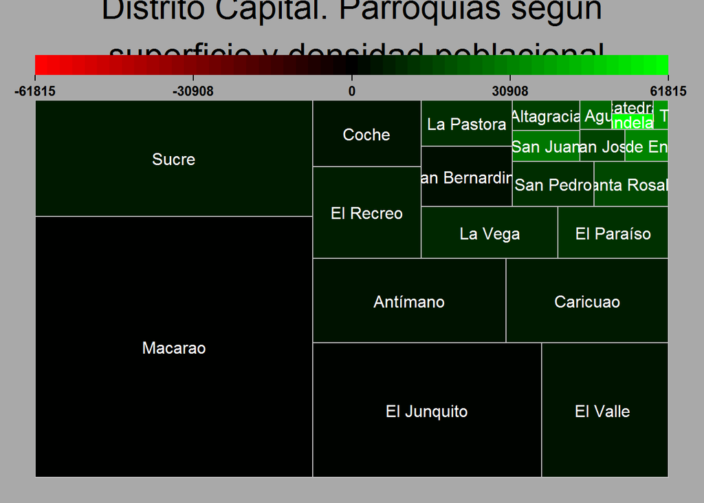

```r
map.market(id=rownames(densidad),
           area = densidad$superficie, # riable que deseo se tome en cuenta para crear el area cuadrada o rectangula
           group = densidad$parroquia, # variable cuya etiqueta aparecera sobre el rectangulo o cuadrado que se forme
           color = densidad$densidad, # variable cuyos valores se tomaran para dar color a los rectangulos o cuadrado. Los valores bajos aparecen en color negro y los colores altos en verde claro
           main = "Distrito Capital. Parroquias segun\n superficie y densidad poblacional")
```

## Interpretación

Si emplearamos este gráfico en un informe, tendríamos que modificar el valor de la escala. No tenemos valores negativos. Por consiguiente, la escala iría de 0 a 61815.

La imagen nos sugiere la áreas hacias las que, idealmente, debería incentivar nuevos urbanismos y zonas de comercio y recreación, eso s las condiciones topográficas lo toleran.